# An Analysis of Wine by Travis Seal

> **Intro:** What you will see below is an analysis of wine. This analysis is a free associative exploration of a great beverage.

> **Our Data :** The data-set that we are going to explore are data about the natural characteristics of wine. There are 13 total variables displayed below. The ones of particular interest are those relating to pH, and acidity levels: fixed.acidity volatile.acidity citric.acid, and pH. There are 1599 observations.

# Univariate Plots Section

> **Summary of entire dataset:**

```
##        X          fixed.acidity   volatile.acidity  citric.acid
##  Min.   :   1.0   Min.   : 4.60   Min.   :0.1200   Min.   :0.000
##  1st Qu.: 400.5   1st Qu.: 7.10   1st Qu.:0.3900   1st Qu.:0.090
##  Median : 800.0   Median : 7.90   Median :0.5200   Median :0.260
##  Mean   : 800.0   Mean   : 8.32   Mean   :0.5278   Mean   :0.271
##  3rd Qu.:1199.5   3rd Qu.: 9.20   3rd Qu.:0.6400   3rd Qu.:0.420
##  Max.   :1599.0   Max.   :15.90   Max.   :1.5800   Max.   :1.000
##  residual.sugar     chlorides       free.sulfur.dioxide
##  Min.   : 0.900   Min.   :0.01200   Min.   : 1.00
##  1st Qu.: 1.900   1st Qu.:0.07000   1st Qu.: 7.00
##  Median : 2.200   Median :0.07900   Median :14.00
##  Mean   : 2.539   Mean   :0.08747   Mean   :15.87
##  3rd Qu.: 2.600   3rd Qu.:0.09000   3rd Qu.:21.00
##  Max.   :15.500   Max.   :0.61100   Max.   :72.00
##  total.sulfur.dioxide    density             pH          sulphates
##  Min.   :  6.00       Min.   :0.9901   Min.   :2.740   Min.   :0.3300
##  1st Qu.: 22.00       1st Qu.:0.9956   1st Qu.:3.210   1st Qu.:0.5500
##  Median : 38.00       Median :0.9968   Median :3.310   Median :0.6200
##  Mean   : 46.47       Mean   :0.9967   Mean   :3.311   Mean   :0.6581
##  3rd Qu.: 62.00       3rd Qu.:0.9978   3rd Qu.:3.400   3rd Qu.:0.7300
##  Max.   :289.00       Max.   :1.0037   Max.   :4.010   Max.   :2.0000
##     alcohol         quality
##  Min.   : 8.40   Min.   :3.000
##  1st Qu.: 9.50   1st Qu.:5.000
##  Median :10.20   Median :6.000
##  Mean   :10.42   Mean   :5.636
##  3rd Qu.:11.10   3rd Qu.:6.000
##  Max.   :14.90   Max.   :8.000
```

```
##    Min. 1st Qu.  Median    Mean 3rd Qu.    Max.
##  0.1200  0.3900  0.5200  0.5278  0.6400  1.5800
```

> **Summary of fixed acidity**

```
##    Min. 1st Qu.  Median    Mean 3rd Qu.    Max.
##    4.60    7.10    7.90    8.32    9.20   15.90
```

> **Summary of pH**

```
##    Min. 1st Qu.  Median    Mean 3rd Qu.    Max.
##   2.740   3.210   3.310   3.311   3.400   4.010
```

# Univariate Analysis

> **Variable Distribution**

We are going to take a look at the distribution of the ‘pH’ variable. Basically I am wondering about the frequency of ‘pH’ in wine for the given data-set.

> **Observations:** The concentration of acidity is between 3 and just below 3.5. I trimmed the tail to increase our focus on the majority of the data.

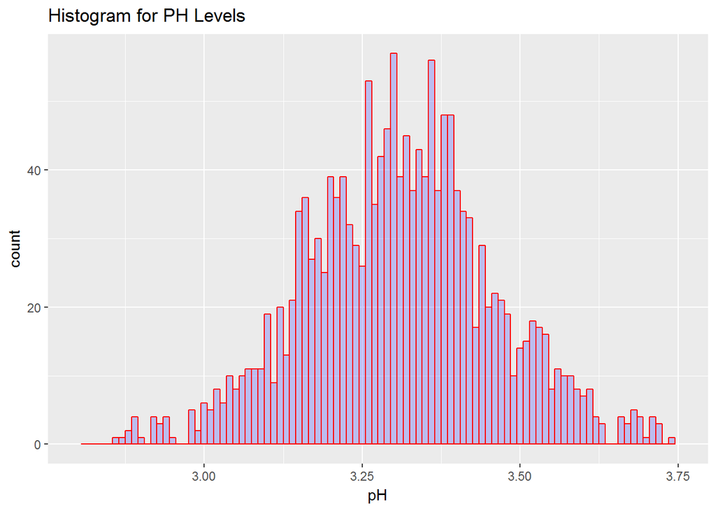

> Here I trimmed the x axis so that we can focus on the majority of the data.

> **Observations:** Its pretty clear that, even though there it is not a linear relationship, there is a general trend of increase observations as pH level increases. This climaxes at ~3.35, then starts to descend at a rate that is **really** close the the rate of ascension, thus we have a normal distribution.

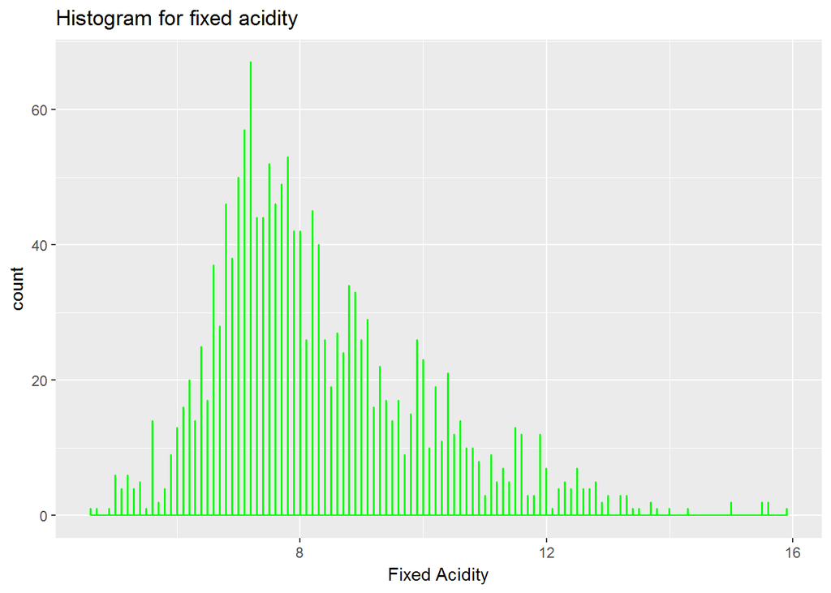

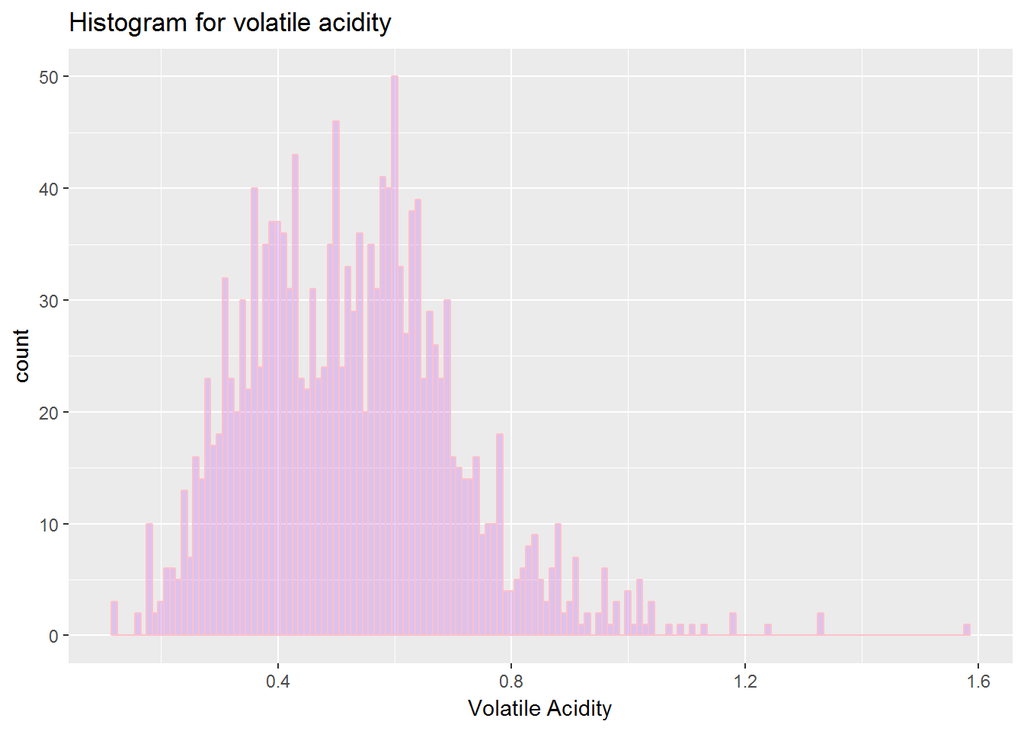

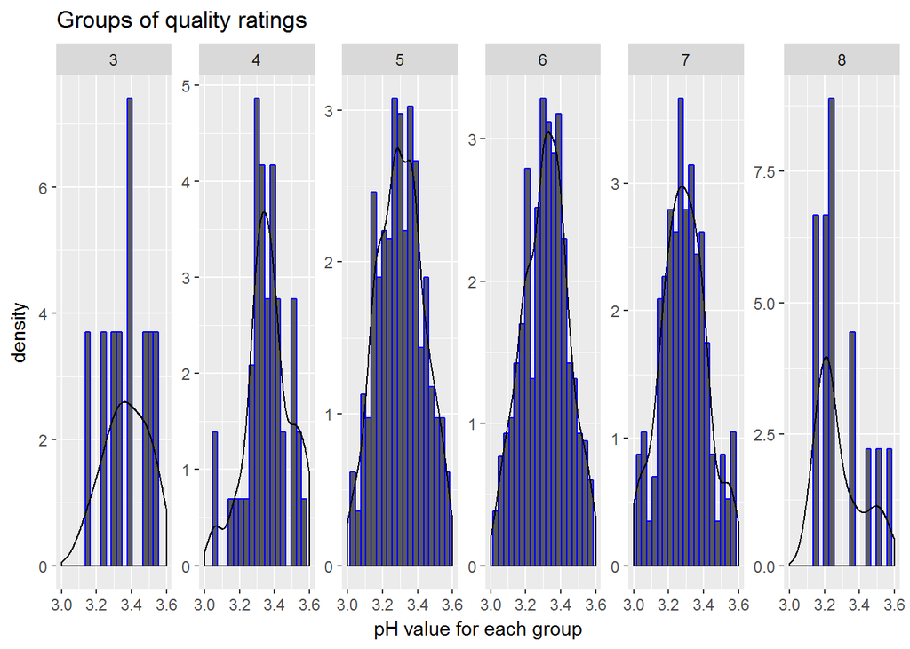

> **observation** This graph shows that 5 of the 6 graphs are normally distributed. Graph 8, or those with the highest quality rating lean to the left, indicating a tendency to like wine with a greater level of acidity. This is because 7 is considered base, and thus a lower number indicates a higher level of acidity.

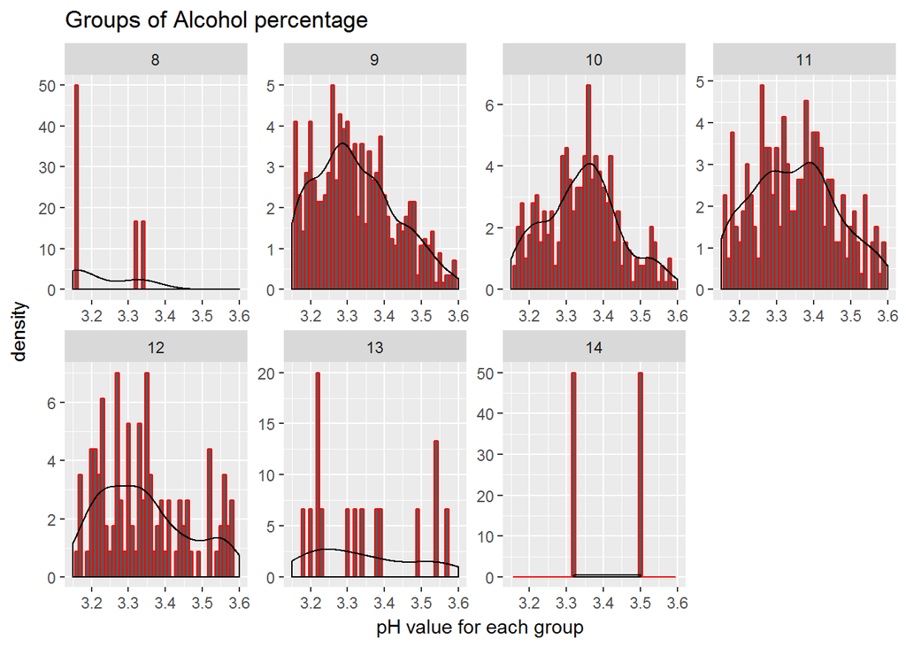

> **Does our alcohol data come from a normal distribution?**

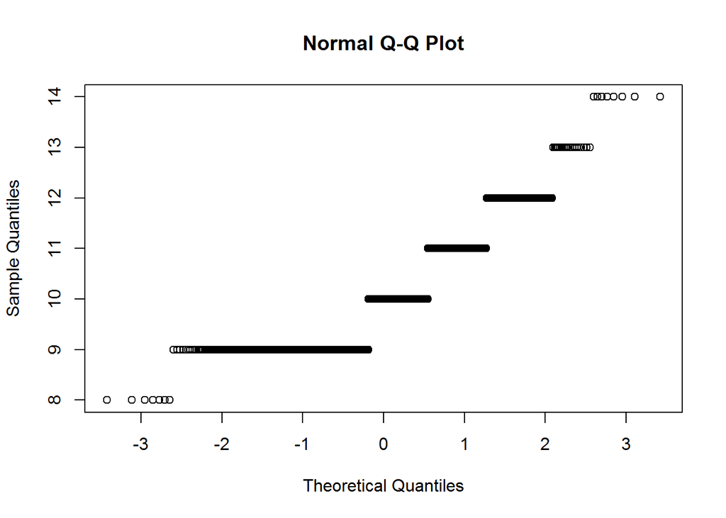

> The above graph is the data the is rounded down to the nerest whole (truncated).

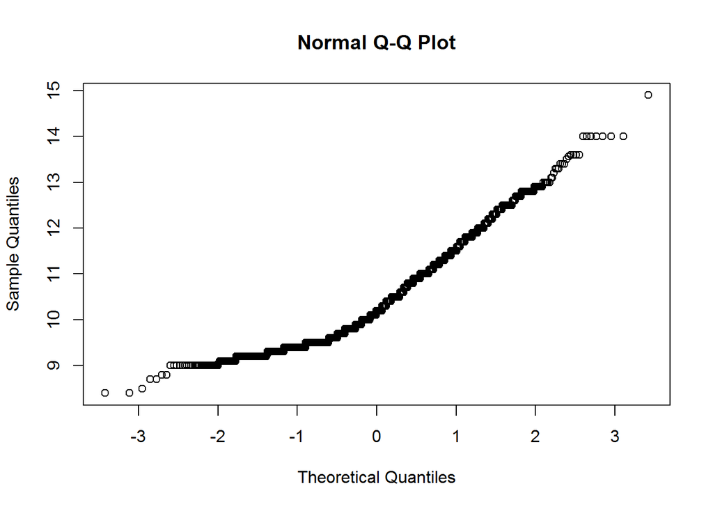

> **This graph does not round the values down to the nearist whole.**

> **The main features** of interest in our data set are the type and category of acids as they relate to wine,quality, and its pH level.

> **Summary**

> **Imperfections** Our data is not perfect, and we can shape our data to make it appear nice to work with by trimming outlines, or changing the bin size. When I grouped the data by alcohol percentage, only half of my graphs turned out ‘normal’ looking.

# Bivariate Plots Section

> **Exploring Relationships**: Acidity is just acidity, right? Turns out there’s more to it. Below is a scatter plot showing the basic relationship between ‘fixed acidity’ and its pH value.

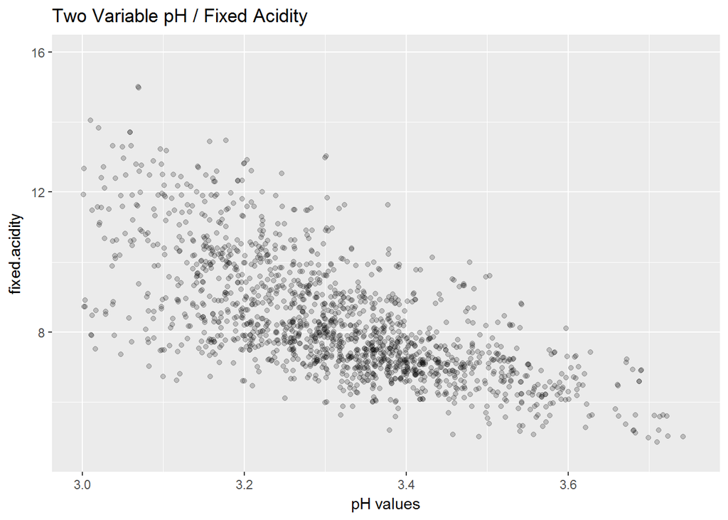

> **Observations** This scatter plot shows us an emerging trend among *all* the data points. It will not show you the *overall relationship* between the two variables. We can start to see a clustering of data ~3.4 pH.

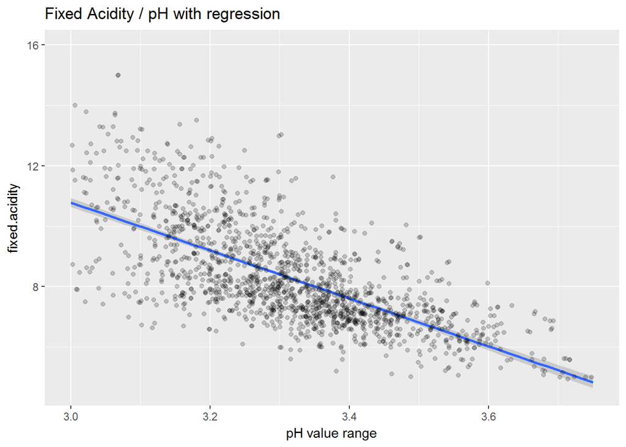

> There seems to be a pretty clear trend as the fixed acidity decreases, so does the acidity level. Remember, acids get more *acidy* as the fall below 7.

# Is there a relationship between pH, and alcohol percentage?

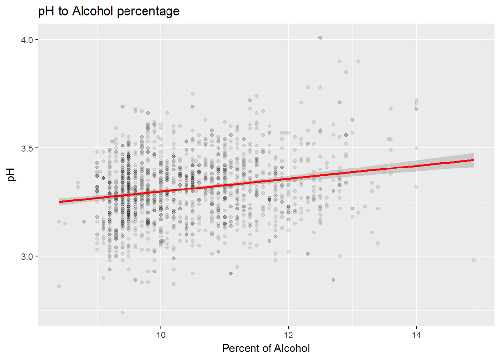

# Is there a correlation between quality and how sweet the wine is?

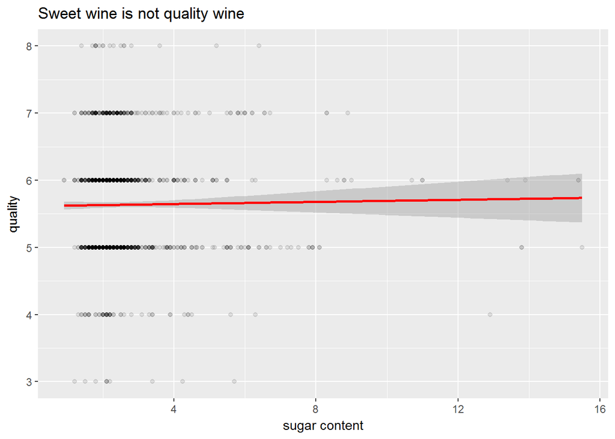

> **Answer** No. Which was a little surprising. The calculated correlation is 0.01. In this case ‘quality’ is somewhat a subjective variable. Sweet wine does not hint at it being good quality.

# Bivariate Analysis

In the given data set, there is no one variable that determines the quality. I did not find a statistically significant correlation between quality, and any other variable. This leads me to conclude that quality must be the product of a combination of variables added together.

> I compared the pH with the acidity levels in wine. This was a natural comparison as pH is the scale by which acidity is measured. This lead me to start asking other questions, like ‘what makes good quality wine’? I stepped through each of the variables and found a correlation of .25 between the amount of sulfates and quality. This value was not strong enough for me to conclude that it is significant, however, it is important to not that it was the strongest out of all of them when measured one at a time.

# Multivariate Plots Section

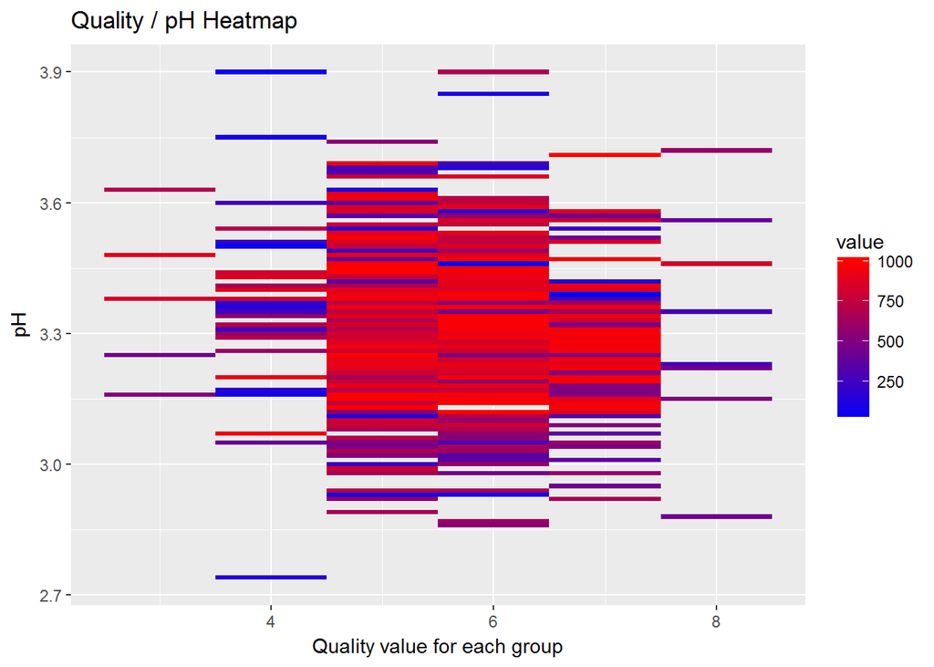

> I melted the data down and created a heatmap of the first 1000 data points. As determined before, there is no clear relationship between quality and pH.

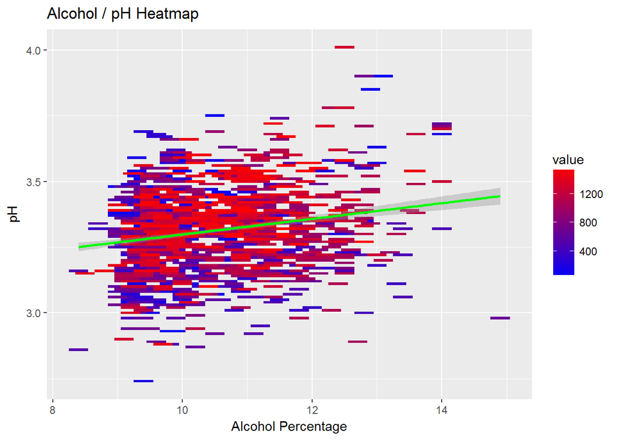

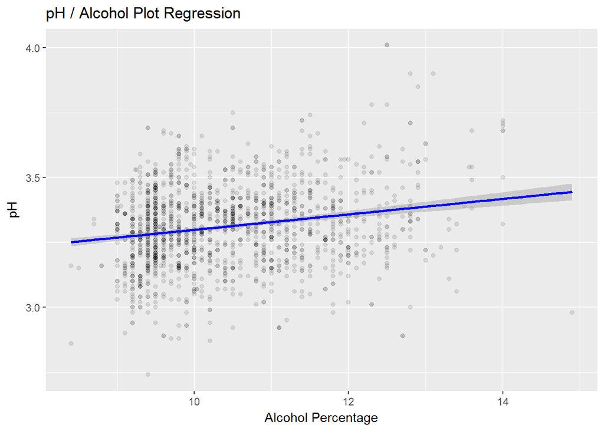

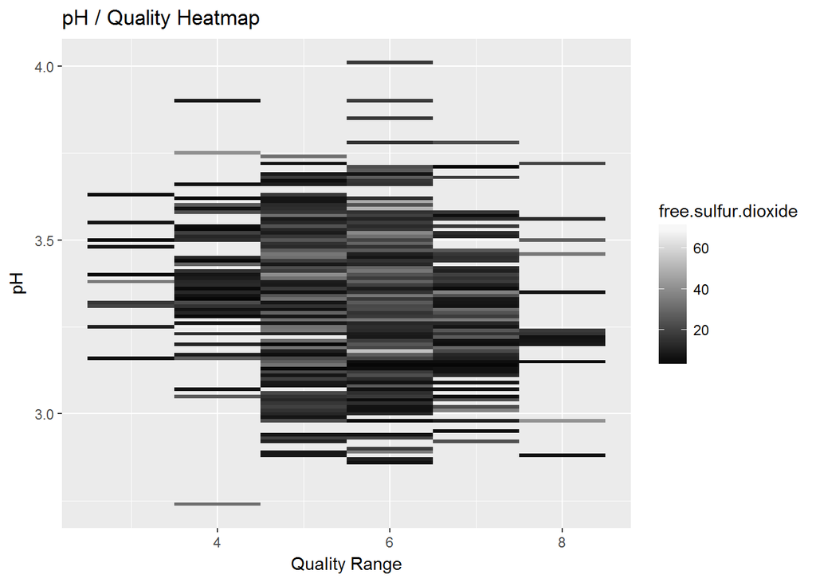

# Multivariate Analysis

## Plot One

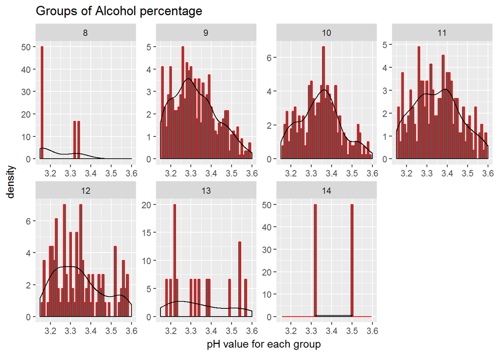

### Description One

> This graph provides really good insight into the wine grouped by alcohol percentage. The percentage is truncated as to create a category. It shows the distribution of of pH for each group. I did find graphs 8, 13 and 14 to be ‘weird’. I believe that these are examples of a case of incomplete data (sample size could be to small), or values that are outliers; if I had more data it is possible that these graphs would begin to look normally distributed.

### Plot Two

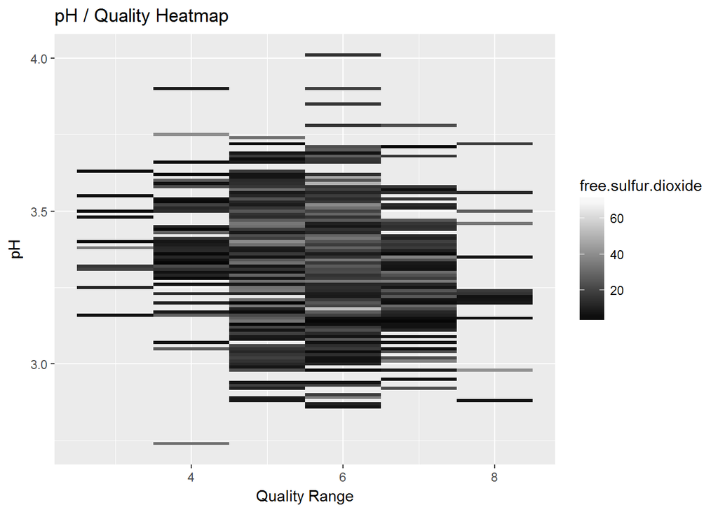

### Description Two

> This map captures three variables: pH, free surfer dioxide, and the quality range. This graph captures how free surfer and pH contribute to the quality. It is obvious that the bulk of the data resides between 4 and 7. This is the sweet spot to manufacture wine at.

### Plot Three

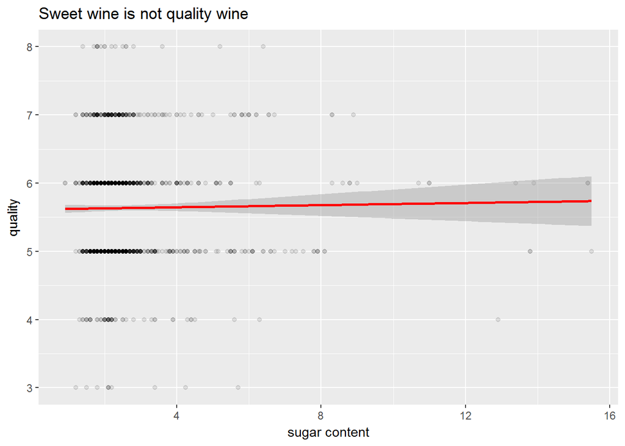

### Description Three

> I like this graph because it absolutely deified by conception of good quality wine. I love sweet wine, and I thought that it would play a factor in the quality. This graph says something different. There is no correlation between how sweet wine is, and its quality. Obviously I don’t know much about wine! There is no meaningful increase in quality with sugar, however, there is something hidden here. According to the data there is a range between ~5 and ~7 that sugar plays a part. But it is not deterministic.

### Reflection

> **Challanges** On a technical level creating the heat-maps proved the most challenging. The solution was to *read the docs*. Another challenge was on a conceptual level, translating narrow data to wide data, and figuring out how to query/graph the data. The solution was to study examples, and read some informational material on the subject. Certainly if I had to scrub, or scrape the data from an online resource, it would be much harder due to the overhead of cleaning, and storing the data.

> **Future work with the data set** The data-set ‘smells’ incomplete. I first noticed this when I grouped the wine by alcohol content. Most of the graphs were normally distributed, while others looked very different. My impression is that if there was more data these graphs could be normalized.